# New Tables: Industry level

- Faire les tableaux suivants:
  - Tableau 4: Kuznet: benchmark → Revision
    - Trouver un tableau avec les déciles pour montrer:
      - turning point croissant pour des villes avec une dominance étatique de plus en plus large
    - Regarder si gdp/cap prix constant
    - Indiquer les turning points dans les tableaux
- Partie 6:
  - Tableau 8:
    - estimer 2 modèles sur des échantillons differents
      - modèle 1 → TCZ *Polluted* Period
      - modèle 2 → Target *polluted*Period
    - Echantillonnage → prendre soit industry soit city industry
      - Big
        - Via Herfhindal
          - benchmark →Revision
      - Foreign
        - via output/capital/employment
      - SOEs
        - via output/capital/employment
      - SPZ
      - Coastal
    - Chaque tableau avec Panel A pour supérieur threshold, Panel B pour inférieur threshold
  - Tableau 9:
    - Enlever SPZ & Coastal
    - estimer 2 modèles sur des échantillons differents
      - modèle 1 → TCZ *Polluted* Period
      - modèle 2 → Target *polluted*Period
    - Idem tableau 8

## Instruction Notebook

The notebook allows the user to construct to different level of aggregation:

- `industry`
- `geocode4_corr` -> city

By default, the `aggregation_param` parameter is set to `industry`. To switch to city, change for `geocode4_corr`. Then launch the notebook for new results

```
Service account storage and Bigquery are now connected.
Service account storage is stored as <google.cloud.storage.client.Client object at 0xa25b4fb10> and accessible with "Storage_account"
Service account Bigquery is stored as <google.cloud.bigquery.client.Client object at 0xa25b64650> and accessible with "bigquery_account"
```

Aggregation Parameter

# Table 8

Estimate the following models using different subsamples:

## Models to estimate

$$ Log SO2 emission _{i k t}=\alpha\left(\text { Period } \times \text { TCZ }_{i} \times \text { Polluting sectors }_{k} \right)+\nu_{i}+Kuznet+\lambda_{t}+\phi_{k}+\epsilon_{i k t} $$$$ Log SO2 emission _{i k t}=\alpha\left(\text { Period } \times \text { Target }_{i} \times \text { Polluting sectors }_{k} \right)+\nu_{i}+Kuznet+\lambda_{t}+\phi_{k}+\epsilon_{i k t} $$$$ Log SO2 emission _{i k t}=\alpha\left(\text { Period } \times \text { Target }_{i} \times \text { Polluting sectors }_{k} \right)+ \\ \beta\left(\text { Period } \times \text { Target }_{i} \times \text { Polluting sectors }_{k} \right) +Kuznet+\nu_{i}+\lambda_{t}+\phi_{k}+\epsilon_{i k t} $$

- Size
  - Via Herfhindal
    - benchmark →Revision
- Foreign
  - via output/capital/employment
- SOEs
  - via output/capital/employment
- SPZ
- Coastal

## Load Data

### Load chinese_city_characteristics from Google Spreadsheet

Feel free to add description about the dataset or any usefull information.

Profiling will be available soon for this dataset

```
Service Google Drive and Docs, Sheet are now connected.
Service Google Drive is stored as <googleapiclient.discovery.Resource object at 0x120d62dd0> and accessible with "drive"
Service Google Doc is stored as <googleapiclient.discovery.Resource object at 0x120ddc0d0> and accessible with "doc"
Service Google Sheet is stored as <googleapiclient.discovery.Resource object at 0x120ee6f50>and accessible with "sheet"
```

```
(30248, 37)
```

### Compute Herfhindal: proxy Size

$$ H=\sum_{i=1}^{N} s_{i}^{2} $$

where $s_i$ is the market share of industry[city] $i$ in a city [industry], and $N$ is the number of firms.

We proceed as follow:

- Step 1: Compute the share [output, capital, employment] by city-industry: `market_share_cit`
- Step 2: compute the sum of squared market share by industry[city]: `Herfindahl_agg_t`
- Step 3: Compute the average across time: `Herfindahl_agg`
- Step 4: Compute the deciles of step 3: `decile_herfhindal_agg`
  - Low decile implies a low concentration within sectors
  - High decile implies a high concentration within sectors

### Compute Ownership: proxy Foreign/SOE

$$\sum output_{agg,o}/ \sum output_{agg}$$

- with $agg$ stands for industry[city]
- $o$ stands for ownership (Foreign vs Domestic or SOE vs private)

#### Foreign vs domestic

We proceed as follow:

- Step 1: Compute the share [output, capital, employment] by industry[city], ownership (Foreign/Domestic): `Share_X_agg_o`
- ~Step 2: Compute dummy when share Foreign above share domestic by industry[city]~
- Step 3: Compute decile by industry[city]-ownership
  - Note, high decile in Foreign means the industry[city] has relatively high share of foreign output, but not in absolule value as in step 2. A decile 9 in foreign can be a decile 2 or 3 in Domestic

#### SOE vs Private

We proceed as follow:

- Step 1: Compute the share [output, capital, employment] by industry[city], ownership (SOE/PRIVATE): `Share_X_agg_o`
- ~Step 2: Compute dummy when share SOE above share domestic by industry[city]~
- Step 3: Compute decile by industry[city]-ownership
  - Note, high decile in SOE means the industry[city] has relatively high share of SOE output, but not in absolule value as in step 2. A decile 9 in SOE can be a decile 2 or 3 in Domestic

### Load TCZ_list_china from Google Spreadsheet

Feel free to add description about the dataset or any usefull information.

Profiling will be available soon for this dataset

### Create R tables

INFO: NumExpr defaulting to 8 threads.

## Table 8 Model 1 and 2

### Categorie Size

#### Mean

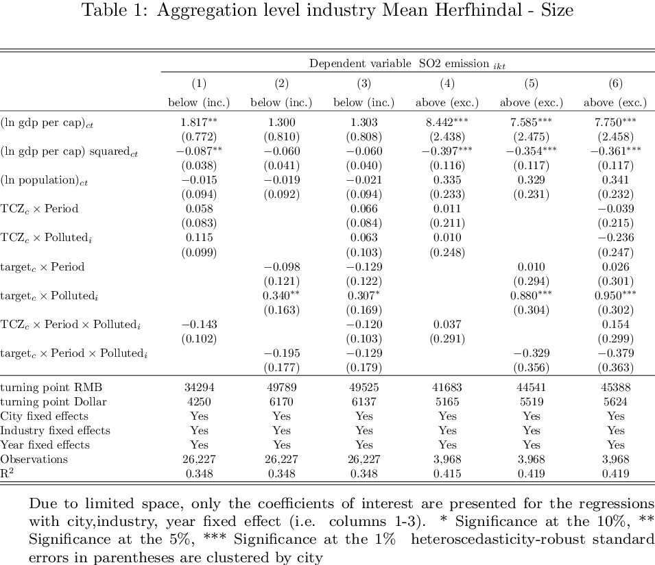

1. TRUE

2. TRUE

3. TRUE

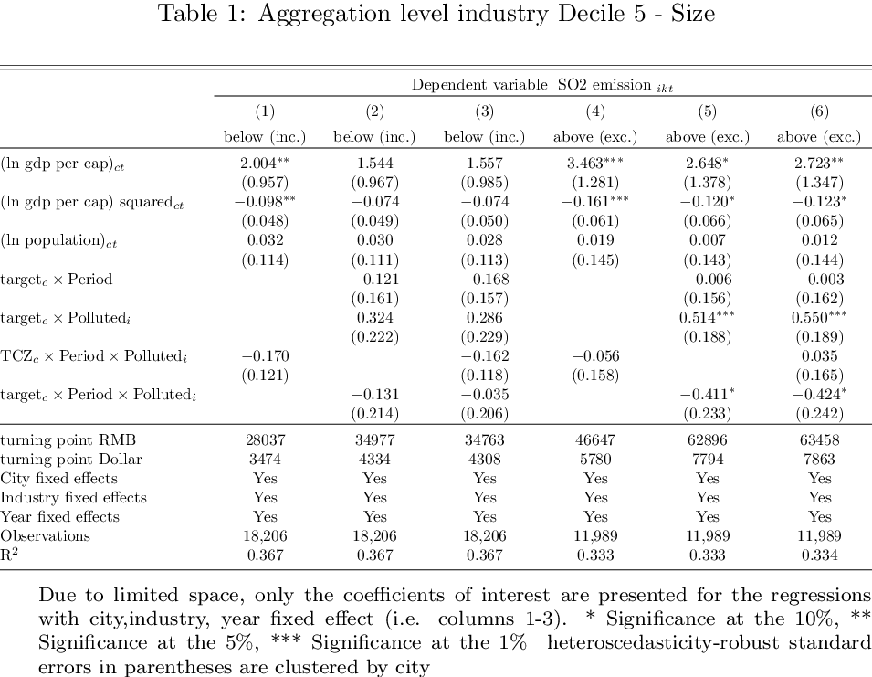

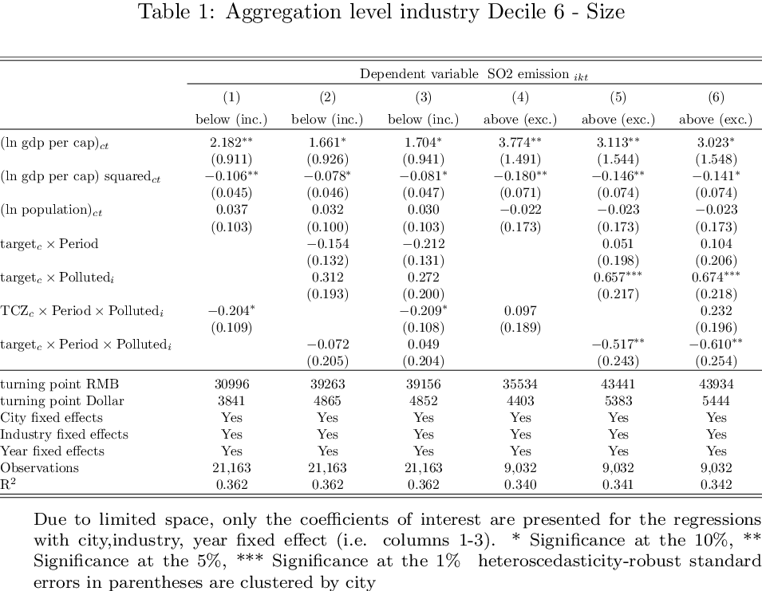

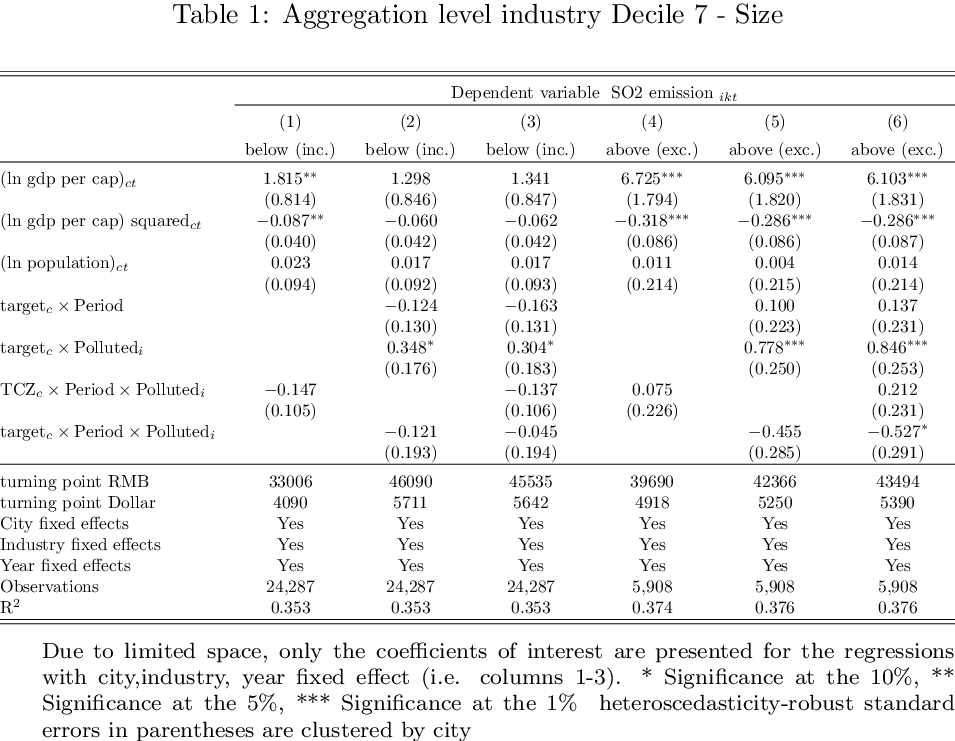

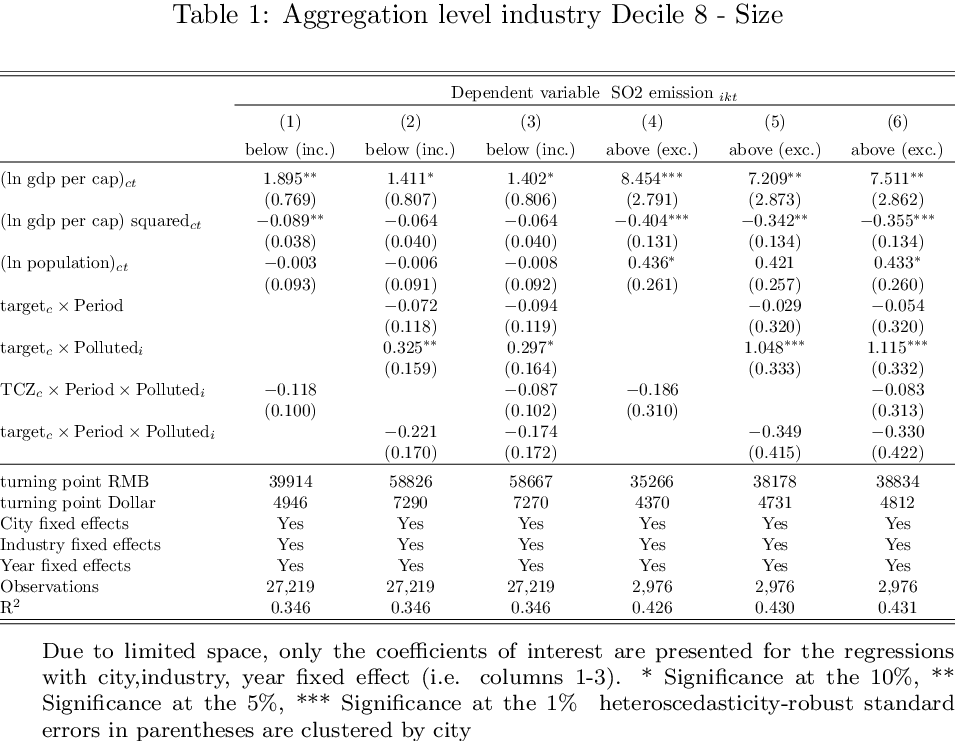

### Categorie Foreign

#### Mean

1. TRUE

2. TRUE

3. TRUE

4. TRUE

5. TRUE

6. TRUE

7. TRUE

8. TRUE

9. TRUE

10. TRUE

11. TRUE

12. TRUE

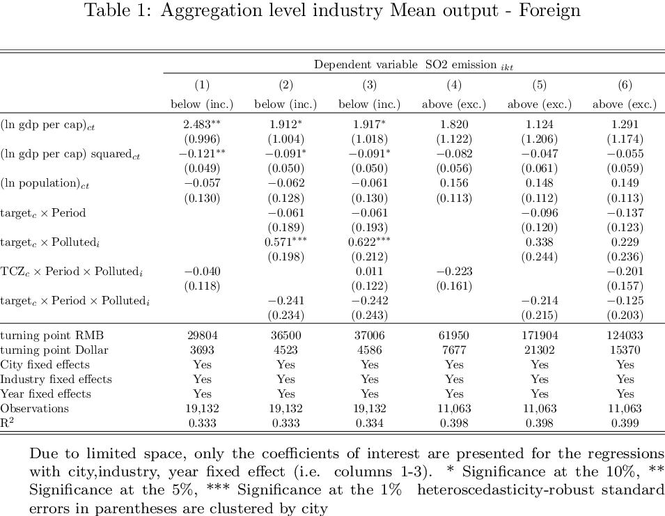

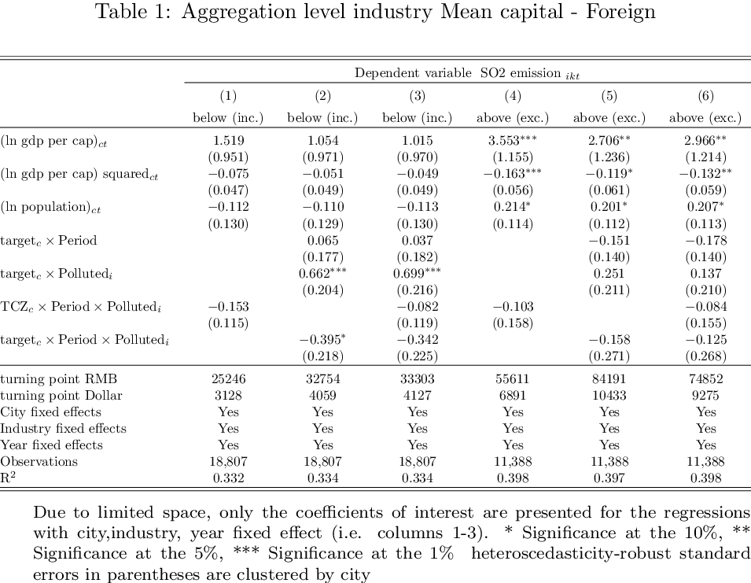

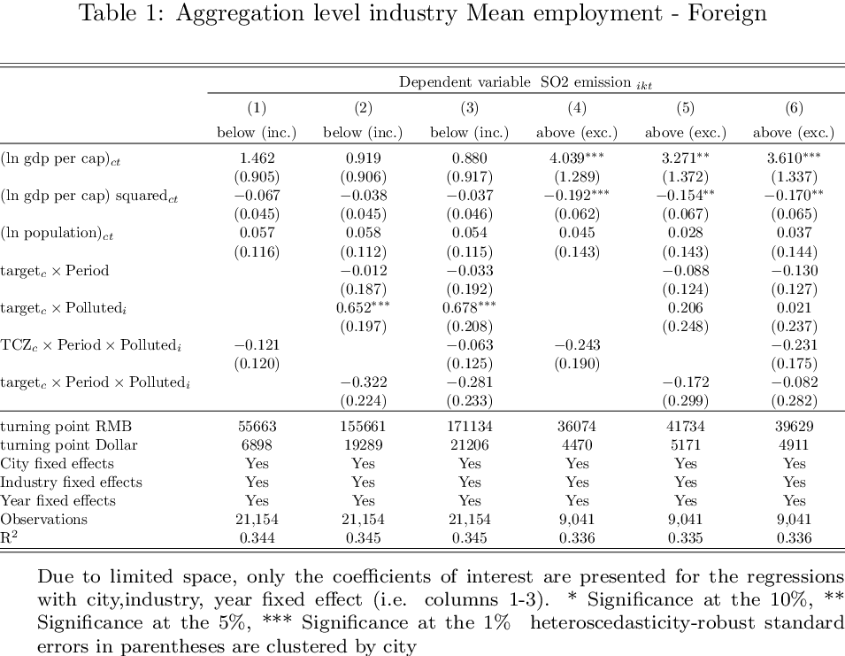

#### Decile 5,6,7,8

1. TRUE

2. TRUE

3. TRUE

4. TRUE

5. TRUE

6. TRUE

7. TRUE

8. TRUE

9. TRUE

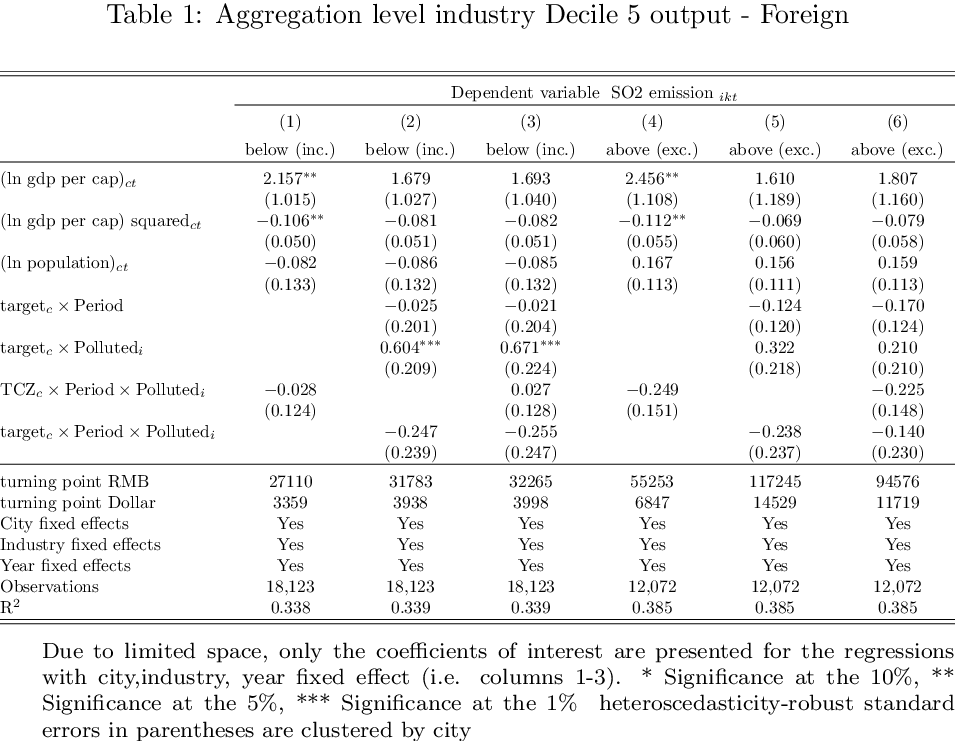

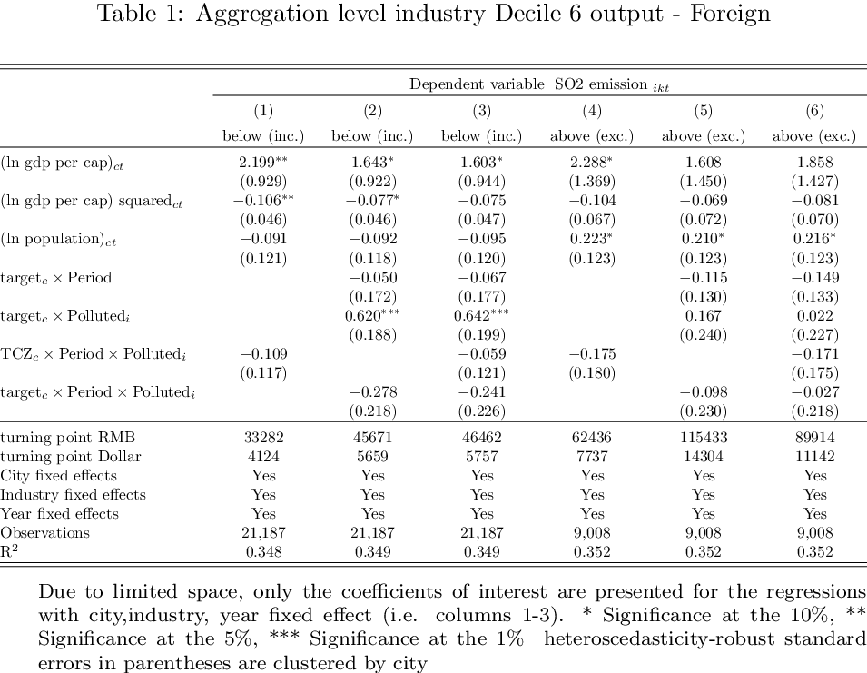

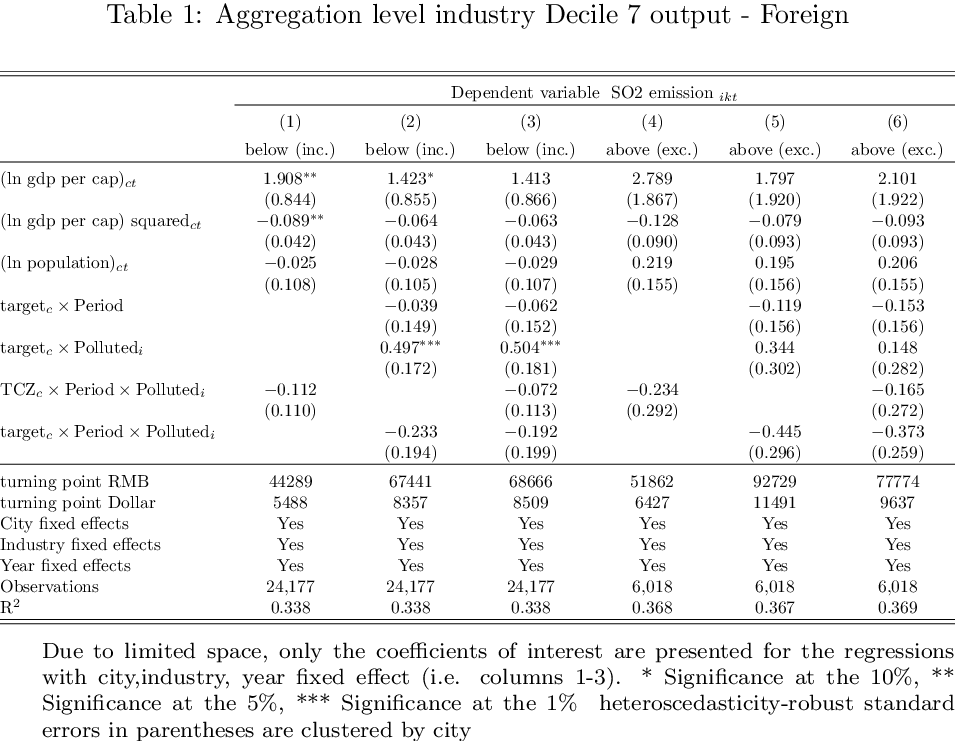

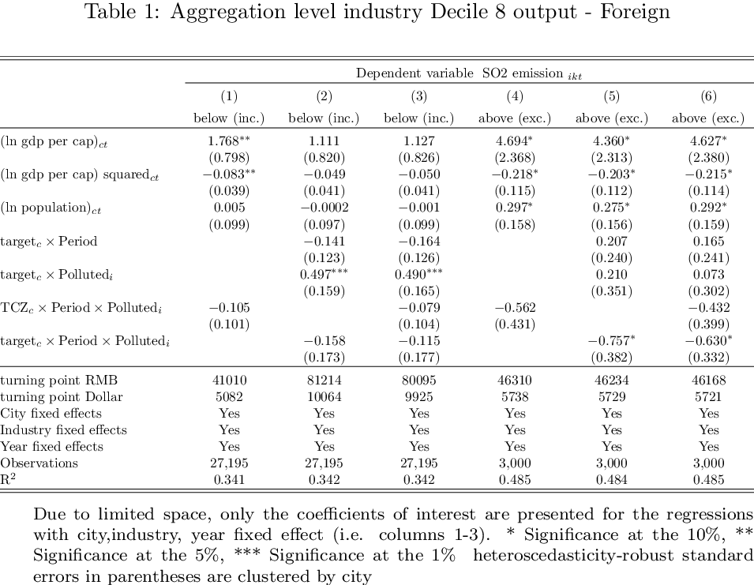

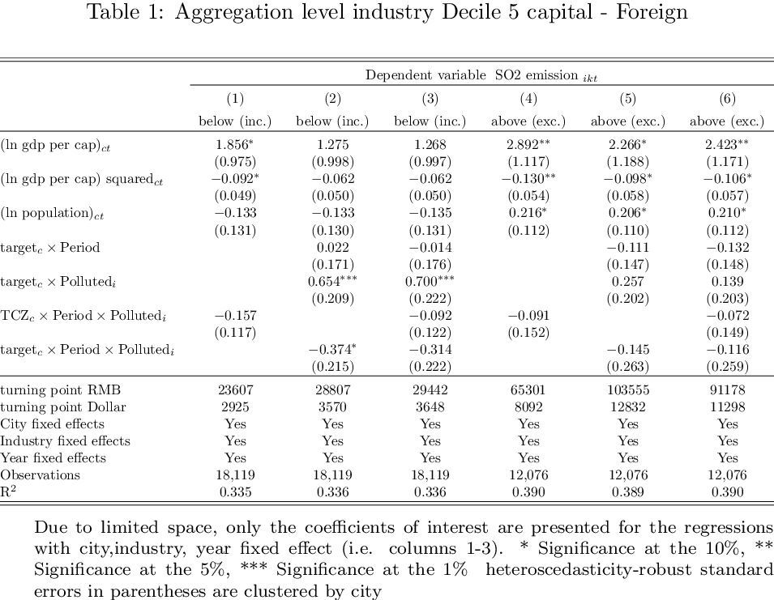

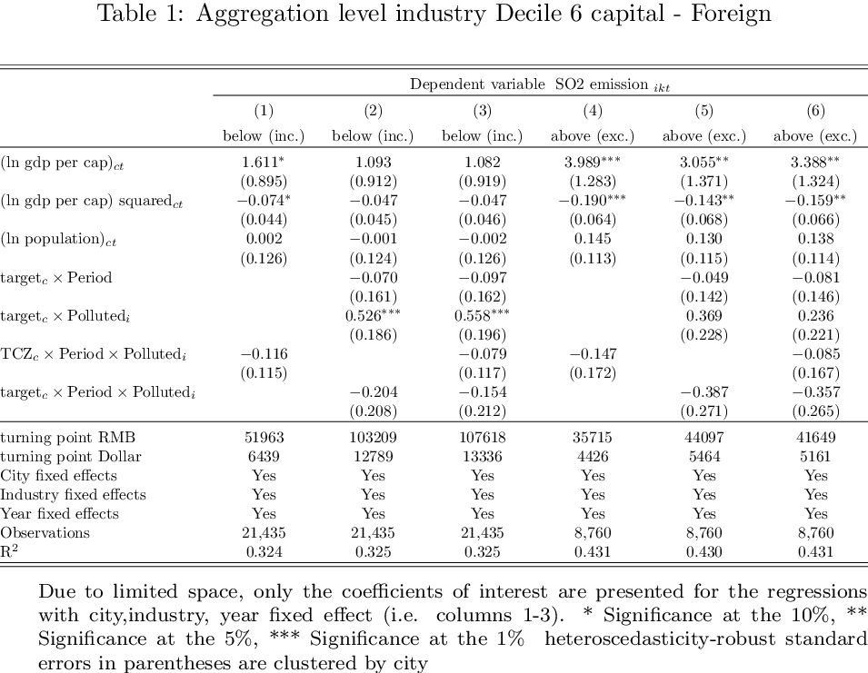

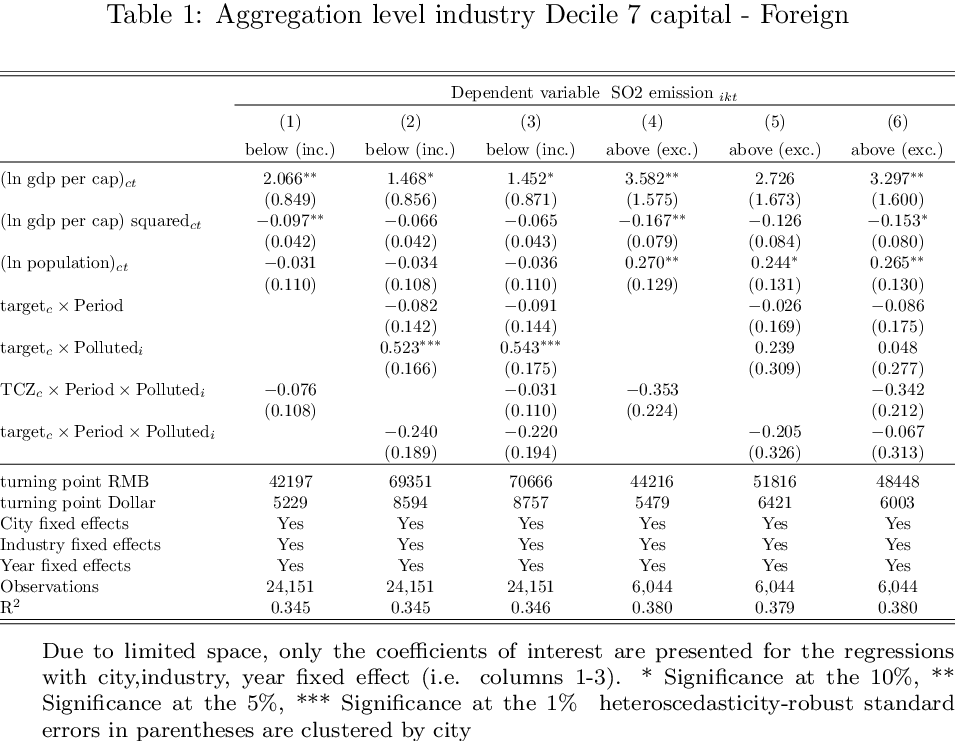

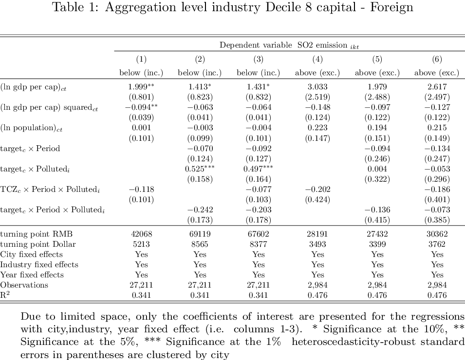

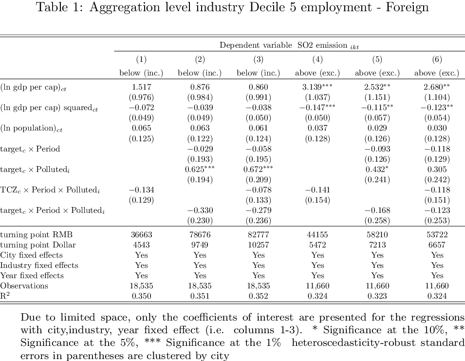

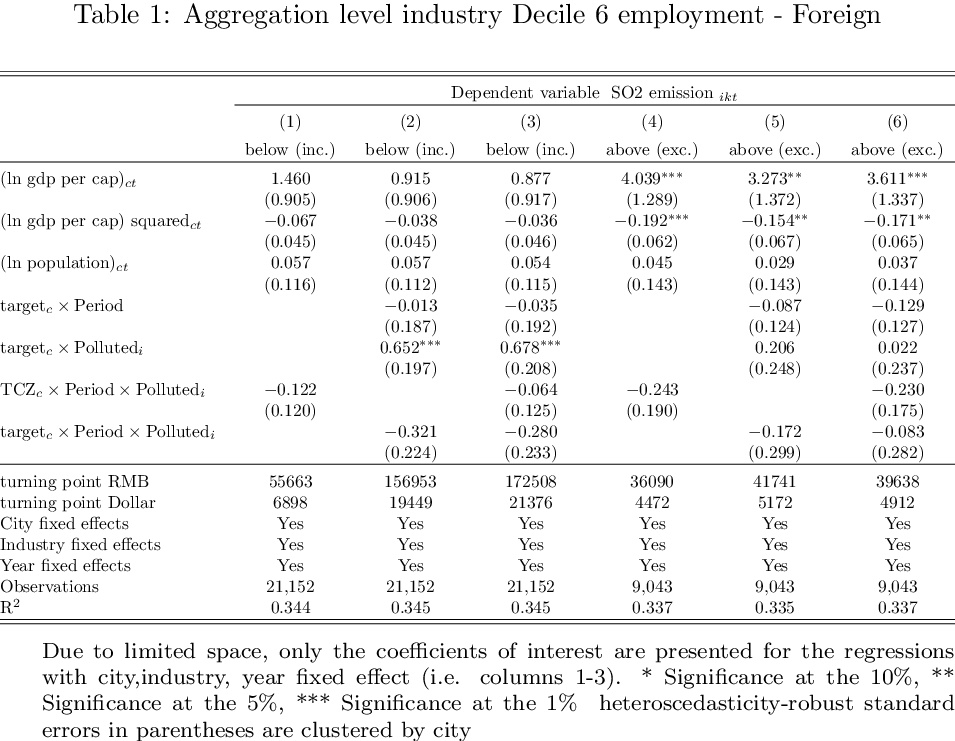

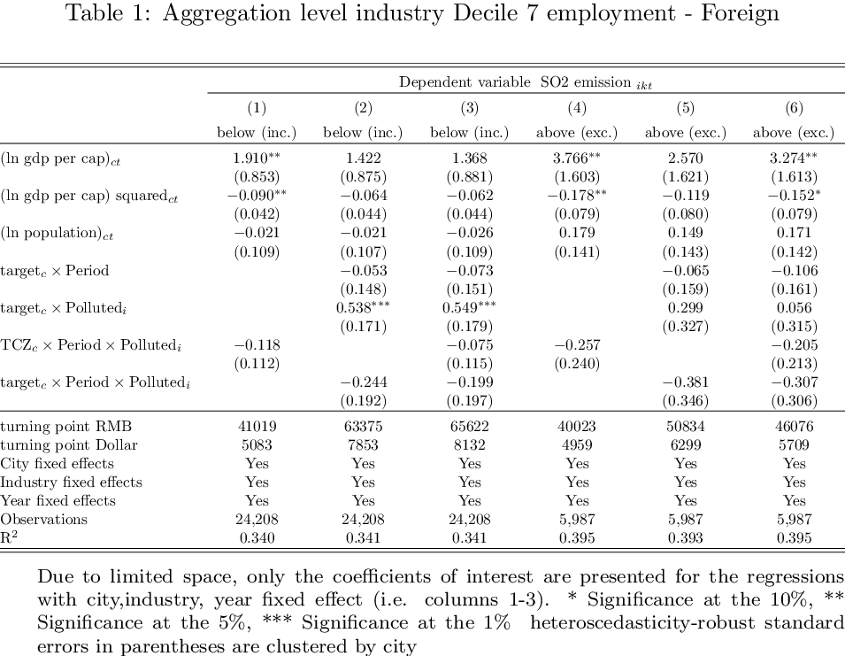

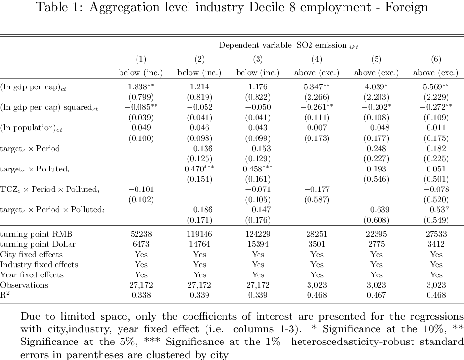

### Categorie SOE

#### Mean

1. TRUE

2. TRUE

3. TRUE

4. TRUE

5. TRUE

6. TRUE

7. TRUE

8. TRUE

9. TRUE

10. TRUE

11. TRUE

12. TRUE

13. TRUE

14. TRUE

15. TRUE

16. TRUE

17. TRUE

18. TRUE

19. TRUE

20. TRUE

21. TRUE

22. TRUE

23. TRUE

24. TRUE

25. TRUE

26. TRUE

27. TRUE

28. TRUE

29. TRUE

30. TRUE

31. TRUE

32. TRUE

33. TRUE

34. TRUE

35. TRUE

36. TRUE

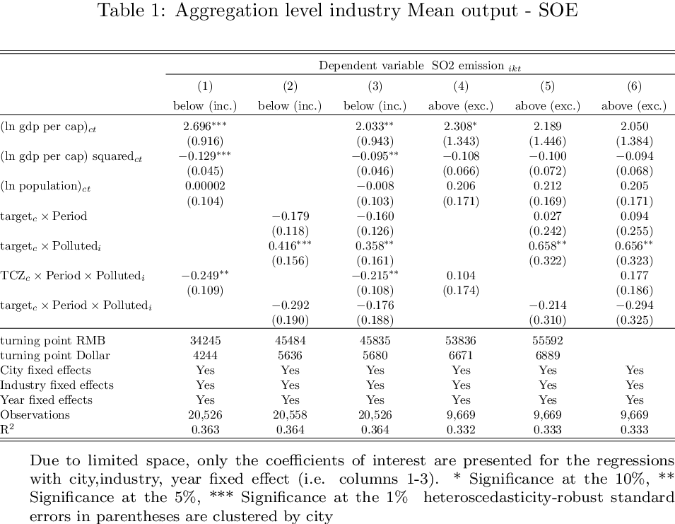

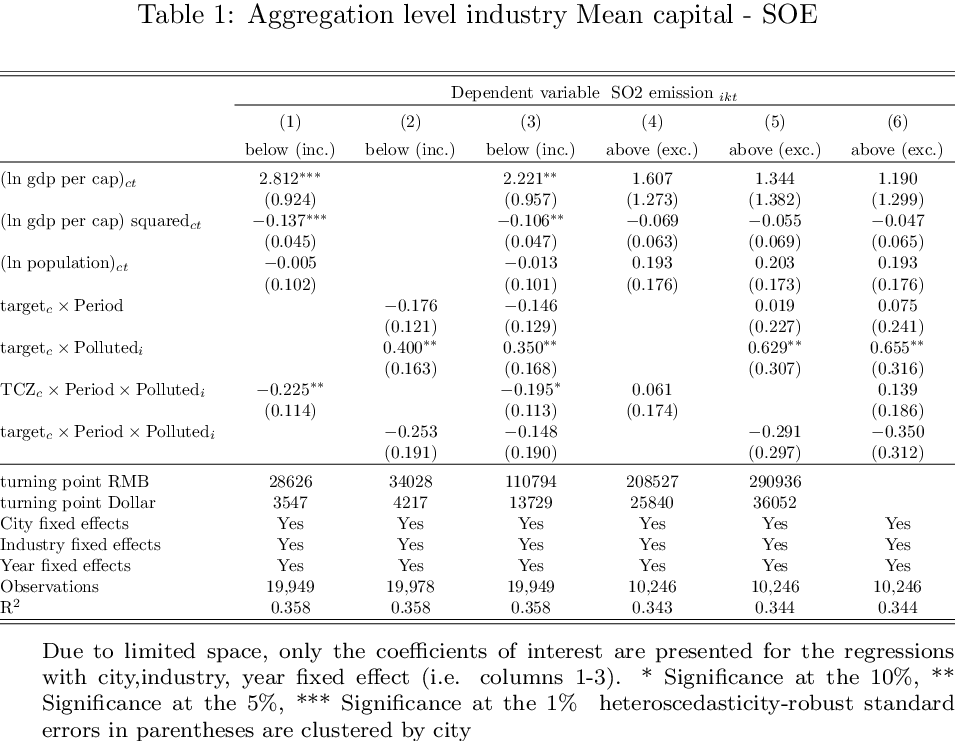

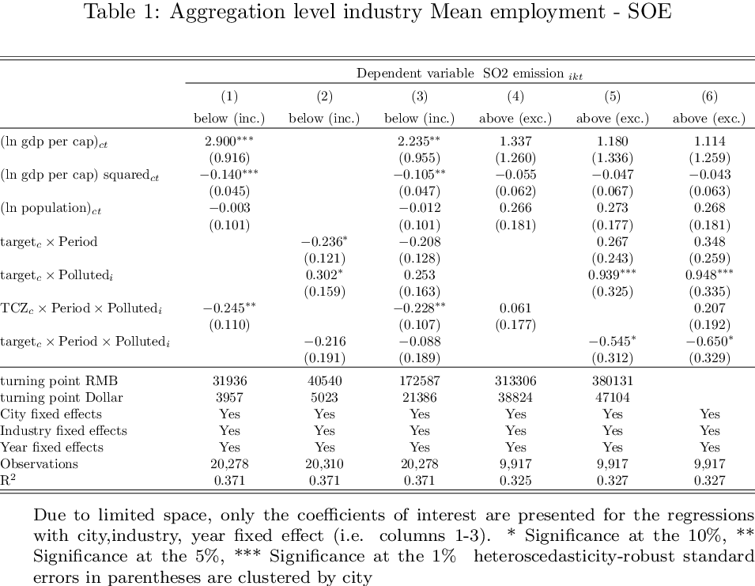

#### Decile

1. TRUE

2. TRUE

3. TRUE

4. TRUE

5. TRUE

6. TRUE

7. TRUE

8. TRUE

9. TRUE

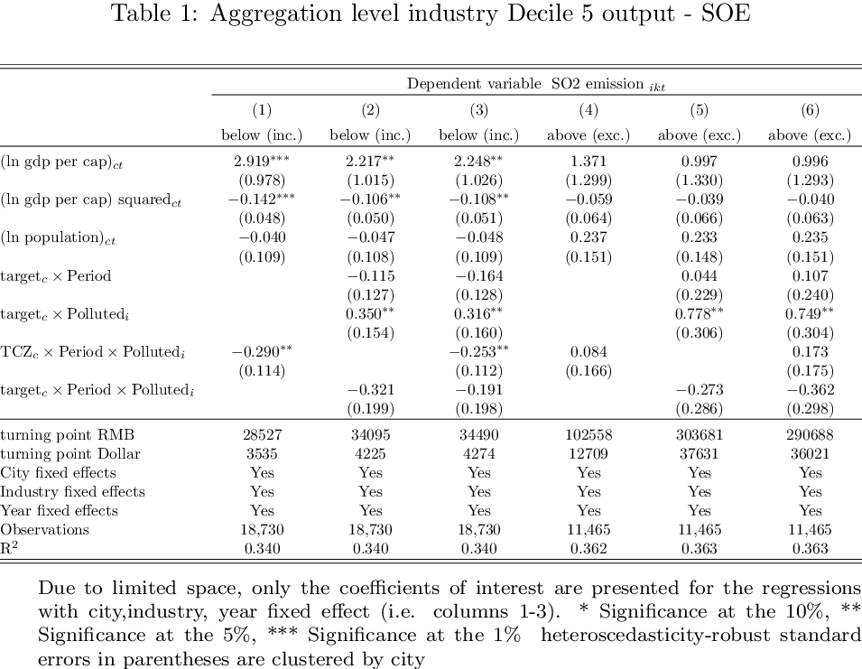

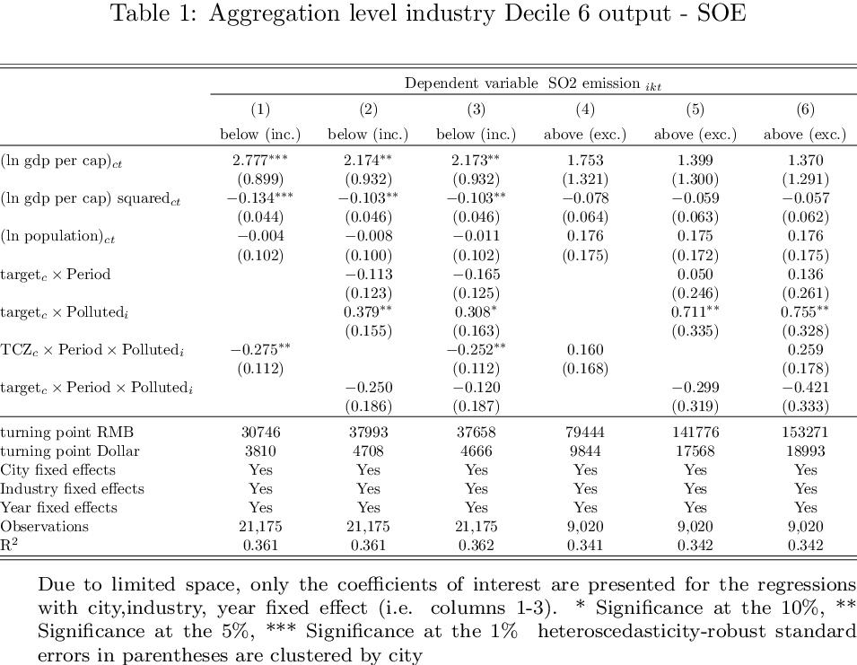

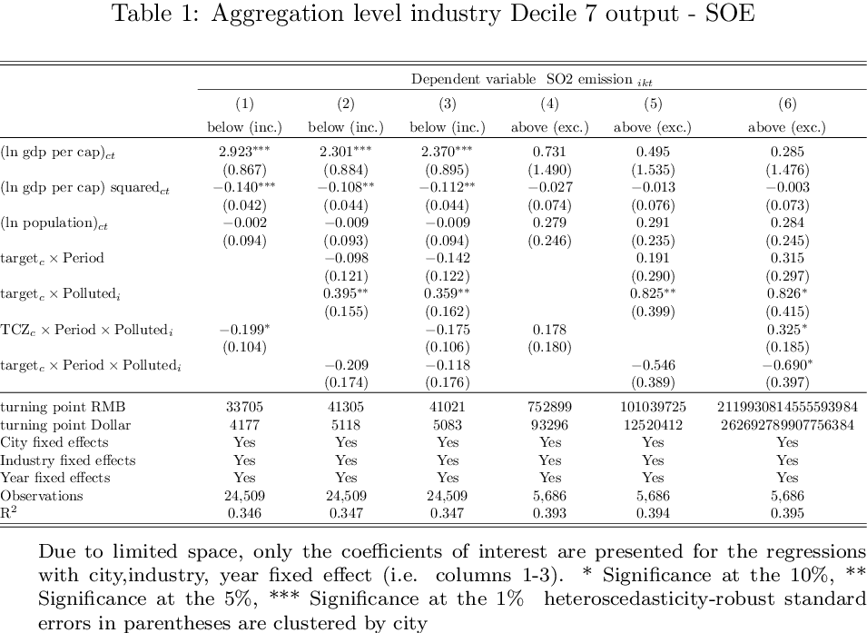

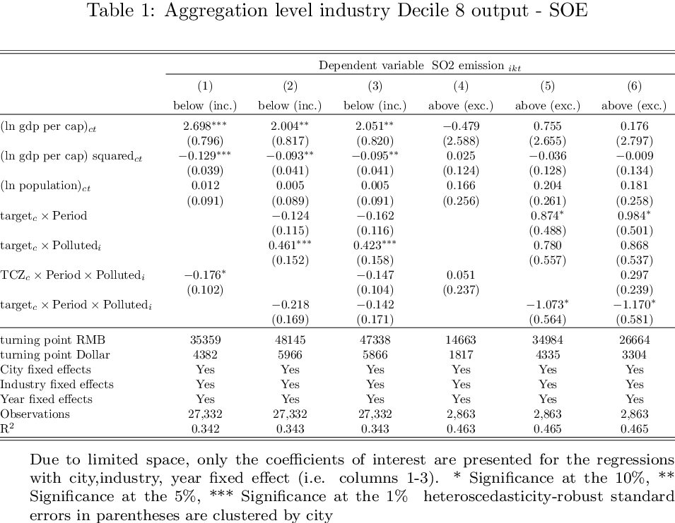

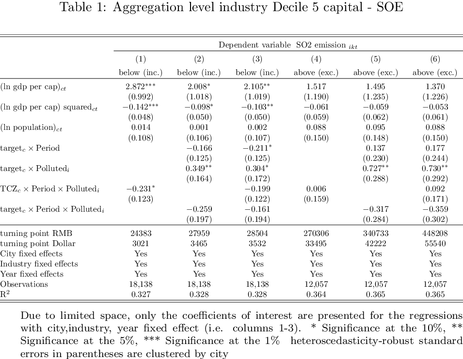

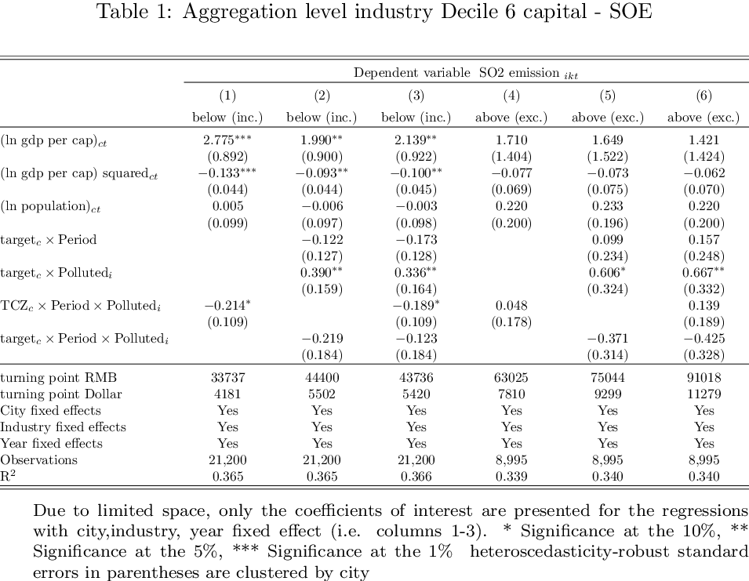

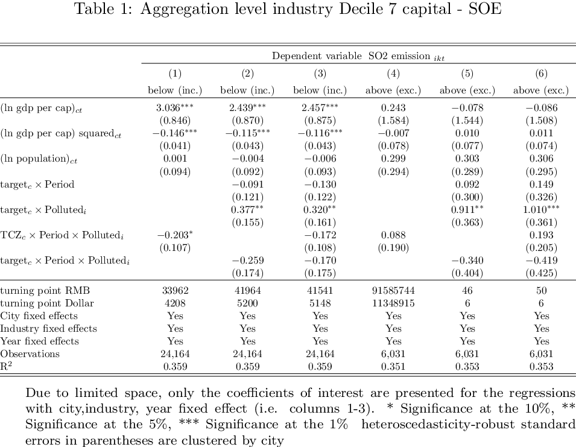

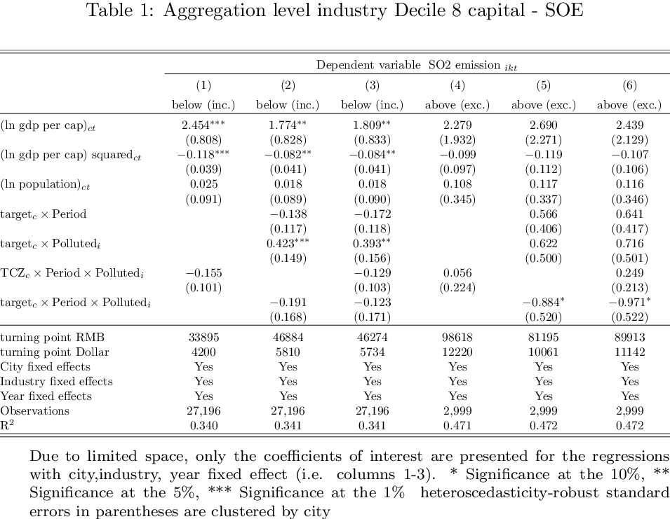